# Getting started with VoxHunt

This vignette gives you an introduction on how to use VoxHunt to swiftly explore the Developing Mouse Brain Atlas ISH data, find brain structure-specific markers and project organoid cells to spatial brain maps.

## Installation

```r
# install.packages('devtools')
devtools::install_github('immunogenomics/presto')
devtools::install_github('quadbiolab/voxhunt')
```

```r
library(voxhunt)
```

## Exploring the ABA

VoxHunt provides a number of convenient functions to explore the Allen Developing Mouse Brain Atlas data computationally using R. To do so, you first need to point VoxHunt to the ABA gene expression data, which you can download [here](https://data.mendeley.com/datasets/g4xg38mwcn/2). Now, we’ll point VoxHunt to the location of these files:

```r
load_aba_data('~/path/to/data')
```

Per default, VoxHunt will not load all of the data at once, but only when we require it.

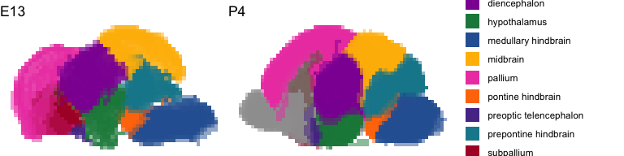

```r
p1 <- plot_annotation('E13')
p2 <- plot_annotation('P4', show_legend=T)
ggarrange(p1, p2, nrow=1)
```

We can also plot the expression of different genes over these voxel maps:

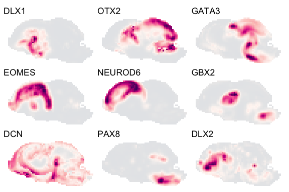

```r
genes <- c('NEUROD6', 'EOMES', 'DCN', 'DLX1', 'DLX2', 'GBX2', 'OTX2', 'GATA3', 'PAX8')
plot_expression('E15', genes = genes) & no_legend()
```

Here we plotted just the sagittal view with a maximum intensity projection for all voxels, sometimes this hides the expression of certain genes. VoxHunt also allows you to define the sections that will be used in the plot:

```r
plot_expression('E15', genes = 'DCN', slices = 5:10) & no_legend()
```

[output not shown]

We can also plot the expression of multiple genes for many coronal sections at the same time:

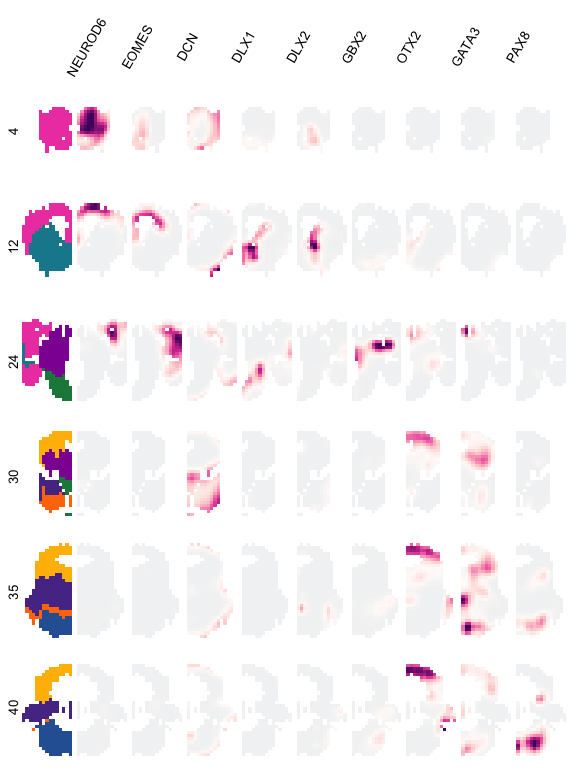

```r
plot_expression(
    'E15',
    genes = genes,
    view = 'slice',
    slices = c(4, 12, 24, 30, 35, 40)
) & no_legend()
```

In addition to plotting well-known canonical markers, we can also perform DE to find specific markers for brain structures we are interested in:

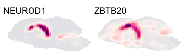

```r
marker_df <- structure_markers('E15', annotation_level = 'custom_4')
hippo_markers <- marker_df %>%
    filter(group=='hippocampus') %>%
    top_n(2, auc)
plot_expression('E15', genes=hippo_markers$gene, nrow=1) & no_legend()
```

## Spatial similarity maps

Ok, now to the interesting part: mapping single cell transcriptomes. Projecting single cells to these spatial maps based on several hundred genes can be very informative about cell type composition of the organoid. First, we load an Seurat object. The example case we use here contains 2300 cells from cerebral organoids.

```r
data(example_seurat)
head(example_seurat@meta.data)
```

```
##                  orig.ident nCount_RNA nFeature_RNA          cluster
## cerebral_HC00013   cerebral   3313.979         3030     ctx_cerebral
## cerebral_HC00030   cerebral   3080.682         2422     ctx_cerebral
## cerebral_HC00036   cerebral   3097.781         2295     ctx_cerebral
## cerebral_HC00040   cerebral   3683.972         4453     ctx_cerebral
## cerebral_HC00043   cerebral   2301.335         1389 dien_ex_cerebral
## cerebral_HC00046   cerebral   2912.589         2368      ge_cerebral
```

Before we start mapping the cells, we’ll do some feature selection to get region specific genes from the ABA:

```r
regional_markers <- structure_markers('E13') %>%
    group_by(group) %>%
    top_n(10, auc) %>%
    {unique(.$gene)}
head(regional_markers)
```

```
## [1] "OTP"    "MEST"   "DLK1"   "PEG10"  "CDH8"   "PLXNC1"
```

Now let’s use these markers to map our single cells to the brain. The `group_name` parameter refers to a metadata column that groups the data into clusters or cell types.

```r
vox_map <- voxel_map(
    example_seurat,
    stage = 'E13',
    group_name = 'cluster',
    genes_use = regional_markers
)
print(vox_map)
```

```
## A VoxelMap object
## 2300 cells mapped to
## 9510 voxels in the E13 mouse brain
## based on 183 features
```

We can first look at the coarse-grained level, what brain structures these cell types are most similar to:

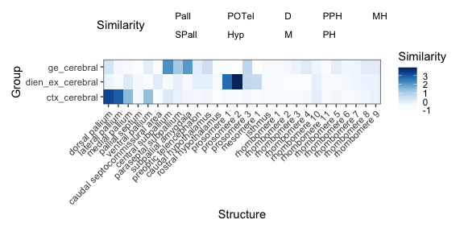

```r
plot_structure_similarity(vox_map, cluster=F)
```

Here, we can already appreciate that our cell types have distinct similarity patterns to certain brain structures, i.e. cortical neurons are similar to the pallium, GE neurons to the subpallium and diencephalic neurons to the diencephalon.

We can further explore our voxel map more spatially. The `plot_map()` function lets us plot spatial similarity maps in a number of different ways. Per default, it will show us a sagittal view of the projection for each of the groups:

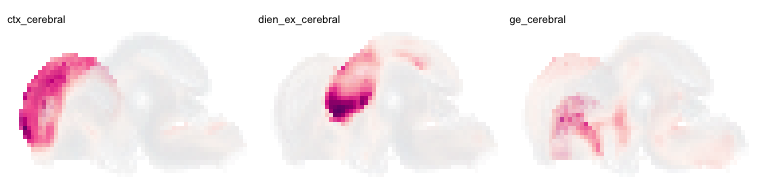

```r
plot_map(vox_map, nrow=1) & no_legend()
```

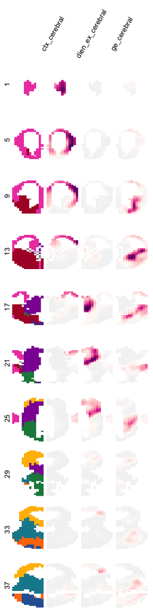

```r
plot_map(vox_map, view='slice', slices=seq(1, 40, 4)) & no_legend()
```

Finally, VoxHunt also allows you to explore similarity maps interactively in 3D with a little help of plotly:

```r
plot_map_3d(
    vox_map,
    show_group = 'ctx_cerebral',
    width = 800,
    height = 600
)
```

## Custom plotting

VoxHunt provides some basic plotting functions to visualize the similarity maps. Of course, you go beyond those if you are familiar with plotting in R. To turn a VoxelMap or ReferenceMap object into a data frame for plotting with e.g. `ggplot()`, VoxHunt provides some convenience functions that return either group (`summarize_groups()`) or structure summaries (`summarize_structures()`) of the map:

```r
group_map <- summarize_groups(vox_map)
head(group_map)
```

```
## # A tibble: 6 x 25
##   voxel group  corr stage structure_name     x     y     z structure_id level_1
##   <chr> <fct> <dbl> <chr> <chr>          <dbl> <dbl> <dbl>        <dbl> <chr>
## 1 E13p… ctx_… 0.413 E13   superficial s…    18    26     0    111220560 forebr…
## 2 E13p… ctx_… 0.404 E13   superficial s…    19    26     0    111220560 forebr…
## 3 E13p… ctx_… 0.477 E13   superficial s…    15    25     0    111220560 forebr…
## 4 E13p… ctx_… 0.456 E13   intermediate …    16    25     0    111220558 forebr…
## 5 E13p… ctx_… 0.435 E13   periventricul…    17    25     0    111220556 forebr…
## 6 E13p… ctx_… 0.426 E13   periventricul…    18    25     0    111220556 forebr…
## # … with 15 more variables: level_2 <chr>, level_3 <chr>, level_4 <chr>,
## #   level_5 <chr>, level_6 <chr>, level_7 <lgl>, level_8 <lgl>, level_9 <lgl>,
## #   level_10 <lgl>, custom_1 <chr>, custom_2 <chr>, custom_3 <chr>,
## #   custom_4 <chr>, stratum <chr>, idx <dbl>
```

```r
struct_map <- summarize_structures(vox_map)
head(struct_map)
```

```
## # A tibble: 6 x 4
##   cell             struct                corr group
##   <chr>            <fct>                <dbl> <chr>
## 1 cerebral_HC00013 caudal hypothalamus 0.0850 ctx_cerebral
## 2 cerebral_HC00030 caudal hypothalamus 0.0292 ctx_cerebral
## 3 cerebral_HC00036 caudal hypothalamus 0.0336 ctx_cerebral
## 4 cerebral_HC00040 caudal hypothalamus 0.117  ctx_cerebral
## 5 cerebral_HC00043 caudal hypothalamus 0.125  dien_ex_cerebral
## 6 cerebral_HC00046 caudal hypothalamus 0.111  ge_cerebral
```

If you’d like to visualize the structure similarities in a low dimensional embedding of single-cell space (e.g. UMAP), you can use `assign_cells()` to assign each cell to the maximum correalting voxel. The resulting dataframe can then be joined with the embedding coordinates or added to the `Seurat` metadata for plotting.

```r
cell_assignment <- assign_cells(vox_map)
head(cell_assignment)
```

```
## # A tibble: 6 x 25
##   voxel  corr cell  stage structure_name     x     y     z structure_id level_1
##   <chr> <dbl> <chr> <chr> <chr>          <dbl> <dbl> <dbl>        <dbl> <chr>
## 1 E13p… 0.639 cere… E13   intermediate …     5    13     2        15983 forebr…
## 2 E13p… 0.566 cere… E13   intermediate …    11    22     0    111220558 forebr…
## 3 E13p… 0.678 cere… E13   superficial s…    10    22     0    111220560 forebr…
## 4 E13p… 0.387 cere… E13   superficial s…    13    26     2    111220560 forebr…
## 5 E13p… 0.438 cere… E13   periventricul…    18    16    11        16399 forebr…
## 6 E13p… 0.379 cere… E13   superficial s…    23    12     1    111220570 forebr…
## # … with 15 more variables: level_2 <chr>, level_3 <chr>, level_4 <chr>,
## #   level_5 <chr>, level_6 <chr>, level_7 <lgl>, level_8 <lgl>, level_9 <lgl>,
## #   level_10 <lgl>, custom_1 <chr>, custom_2 <chr>, custom_3 <chr>,
## #   custom_4 <chr>, stratum <chr>, idx <dbl>
```